# Part 1

David Segovia

2/5/2022

Template file. Code will be included in folded blocks in the output to facilitate grading. Please knit this file and commit both the rmd and the html output. If you add external files to your analysis, please commit them to the files folder in this repository. NOTE: please do not commit large (15MB+) files to GitHub. Instead please denote the origin of the files in your code.

You have been tasked with undertaking a multi-part analysis of homes in Detroit, Michigan. You are provided with a database to facilitate this analysis. This database was constructed from the Detroit Open Data portal and numerous FOIA requests. More information is included in the databases readme. Note that the database must be downloaded via the link provided in the readme.

# Data Manipulation

```
## # Source:   table<sales> [?? x 8]
## # Database: sqlite 3.37.0 [/Users/macbookair/Downloads/PA 470 AI & ML/Detroit
## #   Project/Detroit/detroit.sqlite]
##    parcel_num   sale_date sale_price grantor grantee sale_terms ecf   property_c
##    <chr>        <chr>          <dbl> <chr>   <chr>   <chr>      <chr>      <dbl>
##  1 22059361-5   2011-08-…        500 WAYNE … DETROI… EXEMPT/GO… 7185A        402
##  2 21065621.    2012-03-…          1 CITY O… DETROI… NO CONSID… 3096B        402
##  3 01000616.001 2011-02-…     243421 WAYNE … FANNIE… FORECLOSU… CNDOE        403
##  4 01000616.001 2011-09-…     155100 FANNIE… BIDWEL… BANK SALE… CNDOE        403
##  5 01000617.007 2011-11-…     264323 WAYNE … FEDERA… NO CONSID… CNDOE        403
##  6 01000617.007 2012-04-…     122500 FEDERA… FORD, … BANK SALE… CNDOE        403
##  7 01000617.009 2012-07-…     138000 HUD     KINNI,… BANK SALE… CNDOE        403
##  8 01000617.024 2012-08-…     106000 PUGH, … SHAMRO… NO CONSID… CNDOE        403
##  9 01000617.025 2011-11-…     109000 U S BA… INNES,… NO CONSID… CNDOE        403
## 10 01000618.007 2011-10-…      83000 LAKE T… PETERS… BANK SALE… CNDOE        403
## # … with more rows
```

```
## # A tibble: 276,550 × 8
##    parcel_num   sale_date sale_price grantor grantee sale_terms ecf   property_c
##    <chr>        <chr>          <dbl> <chr>   <chr>   <chr>      <chr>      <dbl>
##  1 22059361-5   2011-08-…        500 WAYNE … DETROI… EXEMPT/GO… 7185A        402
##  2 21065621.    2012-03-…          1 CITY O… DETROI… NO CONSID… 3096B        402
##  3 01000616.001 2011-02-…     243421 WAYNE … FANNIE… FORECLOSU… CNDOE        403
##  4 01000616.001 2011-09-…     155100 FANNIE… BIDWEL… BANK SALE… CNDOE        403
##  5 01000617.007 2011-11-…     264323 WAYNE … FEDERA… NO CONSID… CNDOE        403
##  6 01000617.007 2012-04-…     122500 FEDERA… FORD, … BANK SALE… CNDOE        403
##  7 01000617.009 2012-07-…     138000 HUD     KINNI,… BANK SALE… CNDOE        403
##  8 01000617.024 2012-08-…     106000 PUGH, … SHAMRO… NO CONSID… CNDOE        403
##  9 01000617.025 2011-11-…     109000 U S BA… INNES,… NO CONSID… CNDOE        403
## 10 01000618.007 2011-10-…      83000 LAKE T… PETERS… BANK SALE… CNDOE        403
## # … with 276,540 more rows
```

```
## # Source:   lazy query [?? x 2]
## # Database: sqlite 3.37.0 [/Users/macbookair/Downloads/PA 470 AI & ML/Detroit
## #   Project/Detroit/detroit.sqlite]
##    `year(sale_date)`     n
##                <int> <int>
##  1              2011 19854
##  2              2012 24480
##  3              2013 25955
##  4              2014 41359
##  5              2015 36765
##  6              2016 29524
##  7              2017 29347
##  8              2018 29956
##  9              2019 33025
## 10              2020  6285
```

Using part_1.Rmd in the reports folder, edit that file to accomplish the following tasks:

# Section A: Conduct an exploratory data analysis of homes in Detroit. Offer an overview of relevant trends in the data and data quality issues. Contextualize your analysis with key literature on properties in Detroit.

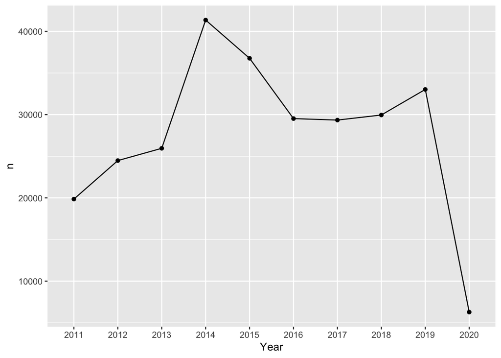

Housing market took a big hit in 2020 because of the pandemic.

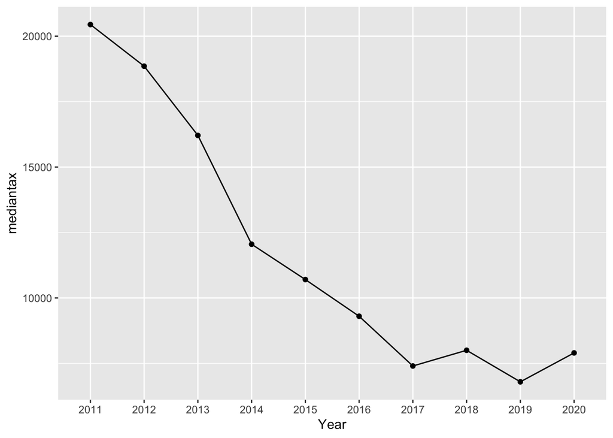

Property taxes have dipped

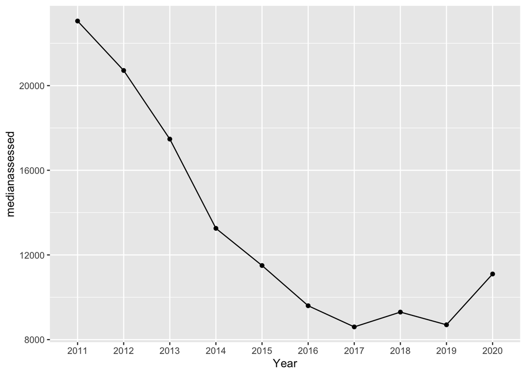

assessed value has also decreased over time

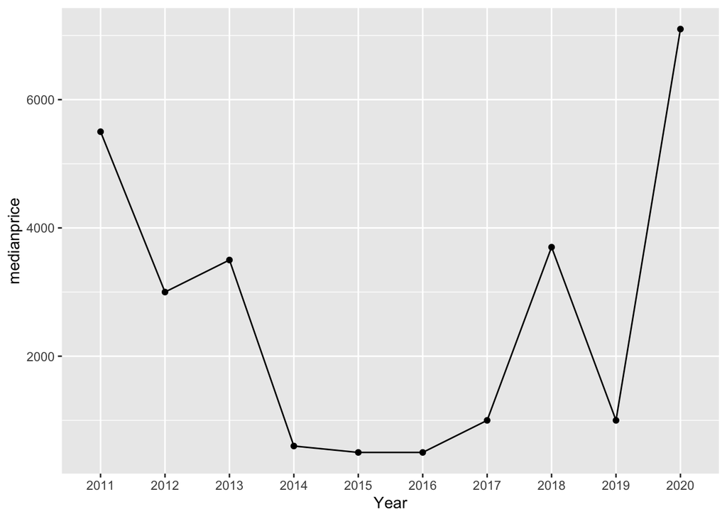

But median sale price has fluctuated but it increased in 2020, a significant increase from 2019

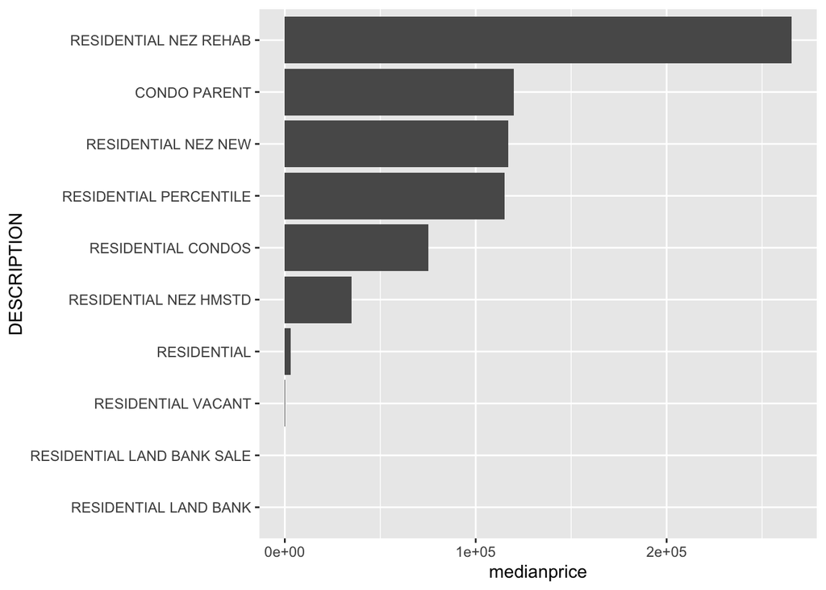

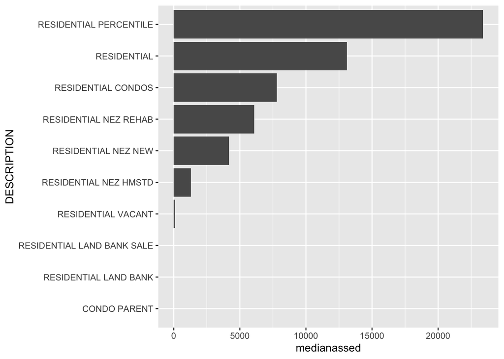

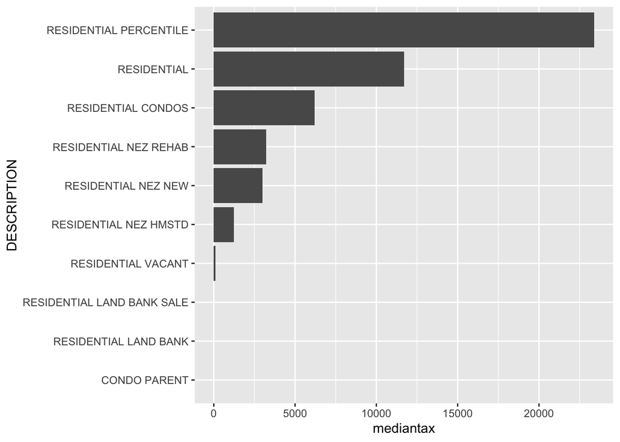

*Measures of central tendency*

```
##     Min.  1st Qu.   Median     Mean  3rd Qu.     Max.
##        0        1     1500    22924    18000 13000000
```

```
## # A tibble: 89,176 × 16
##    parcel_num    Year  Month Day   sale_price grantor   grantee sale_terms ecf
##    <chr>         <chr> <chr> <chr>      <dbl> <chr>     <chr>   <chr>      <chr>
##  1 21065621.     2012  03    15             1 CITY OF … DETROI… NO CONSID… 3096B
##  2 01000749.005  2011  09    06             0 CSER, CH… CSER, … NO CONSID… CNDOE
##  3 01001470.002L 2011  03    26             0 WYCHE, J… WYCHE … NO CONSID… 4124A
##  4 01001534.004  2012  09    26             1 GIGNAC, … R & A … NO CONSID… CNDOD
##  5 01001534.005  2012  09    26             1 GIGNAC, … R & A … NO CONSID… CNDOD
##  6 01001534.008L 2012  09    26             1 GIGNAC, … R & A … NO CONSID… CNDOD
##  7 01002091.     2013  12    10             0 MDNR      MI LAN… NO CONSID… 4120A
##  8 01002453-4    2011  10    31             1 HURST, L… R.W. D… NO CONSID… 4120A
##  9 01002645.     2011  04    29             0 GALLMAN-… DANNIE… NO CONSID… 4120A
## 10 01004162.012  2011  06    10             1 FEDERAL … KRUPA,… NO CONSID… NZH37
## # … with 89,166 more rows, and 7 more variables: property_c <dbl>,
## #   DESCRIPTION <chr>, TYPE <chr>, CATEGORY <chr>, propclass <dbl>,
## #   ASSESSEDVALUE <dbl>, TAXABLEVALUE <dbl>
```

- Mean sale price = $22,924
- Median Sale Price = $1,500
- Minimum Sale Price of $0.00
- Max Sale Price of $13,000,000

Histogram of sales price

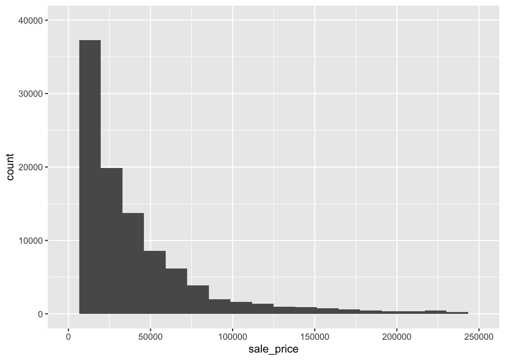

*A few observations*

- Residential Neighborhood Enterprize Zone (NEZ) Rehab properties have one of the highest median sales price but one of the lowest taxable value. They have received tax exemptions, according to this article: https://www.deadlinedetroit.com/articles/24556/detroit_could_double_down_on_tax_break_for_richest_residents
- The histogram displays that prices are skewed to the right. Median would probably be better to use than mean
- 32.24% of the data is made up of values where sale price is equal either 0 or 1
- Median taxable value and the median assessed value have decreased from 2011 to 2020. Median sales price has fluctuated up and down but went up significantly from 2019 to 2020 while the number of housing sales decreased from 2019 to 2020 due to the pandemic.

# Section B: Use cmfproperty to conduct a sales ratio study across the relevant time period. Note that cmfproperty is designed to produce Rmarkdown reports but use the documentation and insert relevant graphs/figures into your report. Look to make this reproducible since you’ll need these methods to analyze your assessment model later on. Detroit has many sales which are not sold at fair market value so some sales should be excluded, but which ones?

```
## [1] "Filtered out non-arm's length transactions"
## [1] "Inflation adjusted to 2020"
```

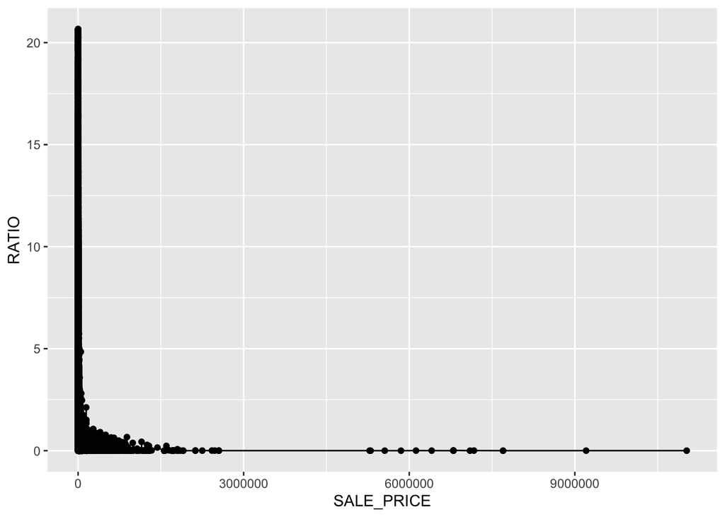

I will probably need to sort these into deciles later but it seems like sales ratios vary systemically, with least expensive homes having the highest assessment relative to the home price but expensive homes have cheaper assessment values, almost 0.

```
## # A tibble: 10 × 4
##    SALE_YEAR TotalArmLengthSales MedianSalePrice MEDIANASSESSEDVALUE
##        <dbl>               <dbl>           <dbl>               <dbl>
##  1      2011               12545           13200              24146
##  2      2012               15124           10000              21598.
##  3      2013               15142           10900              18167
##  4      2014               19068           12500              15040
##  5      2015               16219           12800              12300
##  6      2016               13489           15000              10700
##  7      2017               14253           20000               9500
##  8      2018               15600           29000               9800
##  9      2019               15703           28503               9400
## 10      2020                4160           32000              10400
```

# Section C: Explore trends and relationships with property sales using simple regressions

```
##
## Call:
## lm(formula = SALE_PRICE ~ SALE_YEAR + DESCRIPTION + ASSESSED_VALUE +
##     TAXABLEVALUE, data = salesratio)
##
## Residuals:
##      Min       1Q   Median       3Q      Max
##  -512511   -25551   -14380     4109 10998816
##
## Coefficients:
##                                              Estimate      Std. Error t value
## (Intercept)                           -12408955.19985    257652.82268 -48.162
## SALE_YEAR                                  6266.53497       126.91730  49.375
## DESCRIPTIONRESIDENTIAL                  -208467.32447     27517.02363  -7.576
## DESCRIPTIONRESIDENTIAL CONDOS            -28670.74048     27577.76691  -1.040
## DESCRIPTIONRESIDENTIAL LAND BANK        -206835.15755     28793.75624  -7.183
## DESCRIPTIONRESIDENTIAL LAND BANK SALE   -197623.05810     30681.23525  -6.441
## DESCRIPTIONRESIDENTIAL NEZ HMSTD        -128317.33577     27938.90659  -4.593
## DESCRIPTIONRESIDENTIAL NEZ NEW           -65391.09393     33858.76573  -1.931
## DESCRIPTIONRESIDENTIAL NEZ REHAB          64975.30387     31432.10097   2.067
## DESCRIPTIONRESIDENTIAL PERCENTILE        -58506.54222     29437.71784  -1.987
## DESCRIPTIONRESIDENTIAL VACANT           -167748.06200     27541.02321  -6.091
## ASSESSED_VALUE                                2.00080         0.05367  37.281
## TAXABLEVALUE                                 -0.59933         0.06435  -9.313
##                                                   Pr(>|t|)
## (Intercept)                           < 0.0000000000000002 ***
## SALE_YEAR                             < 0.0000000000000002 ***
## DESCRIPTIONRESIDENTIAL                  0.0000000000000359 ***
## DESCRIPTIONRESIDENTIAL CONDOS                       0.2985
## DESCRIPTIONRESIDENTIAL LAND BANK        0.0000000000006837 ***
## DESCRIPTIONRESIDENTIAL LAND BANK SALE   0.0000000001189347 ***
## DESCRIPTIONRESIDENTIAL NEZ HMSTD        0.0000043775030773 ***
## DESCRIPTIONRESIDENTIAL NEZ NEW                      0.0534 .
## DESCRIPTIONRESIDENTIAL NEZ REHAB                    0.0387 *
## DESCRIPTIONRESIDENTIAL PERCENTILE                   0.0469 *
## DESCRIPTIONRESIDENTIAL VACANT           0.0000000011260573 ***
## ASSESSED_VALUE                        < 0.0000000000000002 ***
## TAXABLEVALUE                          < 0.0000000000000002 ***
## ---
## Signif. codes:  0 '***' 0.001 '**' 0.01 '*' 0.05 '.' 0.1 ' ' 1
##
## Residual standard error: 116700 on 141290 degrees of freedom
## Multiple R-squared:  0.1167, Adjusted R-squared:  0.1166
## F-statistic:  1556 on 12 and 141290 DF,  p-value: < 0.00000000000000022
```

```
## # A tibble: 13 × 5
##    term                                   estimate std.error statistic   p.value
##    <chr>                                     <dbl>     <dbl>     <dbl>     <dbl>
##  1 (Intercept)                            -1.24e+7   2.58e+5    -48.2  0
##  2 SALE_YEAR                               6.27e+3   1.27e+2     49.4  0
##  3 DESCRIPTIONRESIDENTIAL                 -2.08e+5   2.75e+4     -7.58 3.59e- 14
##  4 DESCRIPTIONRESIDENTIAL CONDOS          -2.87e+4   2.76e+4     -1.04 2.99e-  1
##  5 DESCRIPTIONRESIDENTIAL LAND BANK       -2.07e+5   2.88e+4     -7.18 6.84e- 13
##  6 DESCRIPTIONRESIDENTIAL LAND BANK SALE  -1.98e+5   3.07e+4     -6.44 1.19e- 10
##  7 DESCRIPTIONRESIDENTIAL NEZ HMSTD       -1.28e+5   2.79e+4     -4.59 4.38e-  6
##  8 DESCRIPTIONRESIDENTIAL NEZ NEW         -6.54e+4   3.39e+4     -1.93 5.34e-  2
##  9 DESCRIPTIONRESIDENTIAL NEZ REHAB        6.50e+4   3.14e+4      2.07 3.87e-  2
## 10 DESCRIPTIONRESIDENTIAL PERCENTILE      -5.85e+4   2.94e+4     -1.99 4.69e-  2
## 11 DESCRIPTIONRESIDENTIAL VACANT          -1.68e+5   2.75e+4     -6.09 1.13e-  9
## 12 ASSESSED_VALUE                          2.00e+0   5.37e-2     37.3  9.93e-303
## 13 TAXABLEVALUE                           -5.99e-1   6.44e-2     -9.31 1.26e- 20
```

```
## # A tibble: 1 × 12
##   r.squared adj.r.squared   sigma statistic p.value    df   logLik    AIC    BIC
##       <dbl>         <dbl>   <dbl>     <dbl>   <dbl> <dbl>    <dbl>  <dbl>  <dbl>
## 1     0.117         0.117 116728.     1556.       0    12  -1.85e6 3.70e6 3.70e6
## # … with 3 more variables: deviance <dbl>, df.residual <int>, nobs <int>
```

```
##                    GVIF Df GVIF^(1/(2*Df))
## SALE_YEAR      1.155318  1        1.074857
## DESCRIPTION    1.093258  9        1.004966
## ASSESSED_VALUE 6.274239  1        2.504843
## TAXABLEVALUE   6.539896  1        2.557322
```

# Section D: Explore trends and relationships with foreclosures using simple regressions

1 = fore closure, NA = no(we will need to change this later to 0)

```
## # A tibble: 10 × 2
##     Year     n
##    <dbl> <int>
##  1  2011 19854
##  2  2012 24480
##  3  2013 25955
##  4  2014 41359
##  5  2015 36765
##  6  2016 29524
##  7  2017 29347
##  8  2018 29956
##  9  2019 33025
## 10  2020  6285
```

```
##  2002  2003  2004  2005  2006  2007  2008  2009  2010  2011  2012  2013  2014
##   246  2484  2034  2084  5108  2252  4111  7986 11632 12999 20040 18785 23845
##  2015  2016  2017  2018  2019
## 24340 12590  6289  3880  2748
```

```
##
##      1      2      3      4      5      6      7      8     10
## 109084  23586   2199    120     14      3      2      1      1
```

Regression 1) I can run a linear regression estimating total number of foreclosures 2) OR Logistic regression: the property either foreclosed (1) or not(0).

https://www.foxbusiness.com/politics/detroit-reveals-tentative-compensation-plan-overtaxed-foreclosed-homeowners

This article explains that the city of Detroit overtaxed homeowners and assessed properties far more than 50% of its market value. Let’s see what a simple regression gives us with sales ratio.

```
##
## Call:
## glm(formula = foreclosed_catg ~ RATIO + SALE_YEAR, family = binomial,
##     data = merged)
##
## Deviance Residuals:
##     Min       1Q   Median       3Q      Max
## -2.8316  -1.0224  -0.8074   1.2337   1.7980
##
## Coefficients:
##                Estimate  Std. Error z value            Pr(>|z|)
## (Intercept) -319.016129    4.870822  -65.50 <0.0000000000000002 ***
## RATIO          0.253264    0.003123   81.10 <0.0000000000000002 ***
## SALE_YEAR      0.157942    0.002416   65.38 <0.0000000000000002 ***
## ---
## Signif. codes:  0 '***' 0.001 '**' 0.01 '*' 0.05 '.' 0.1 ' ' 1
##
## (Dispersion parameter for binomial family taken to be 1)
##
##     Null deviance: 191919  on 141304  degrees of freedom
## Residual deviance: 182262  on 141302  degrees of freedom
## AIC: 182268
##
## Number of Fisher Scoring iterations: 4
```

```
## # A tibble: 1 × 8
##   null.deviance df.null  logLik     AIC     BIC deviance df.residual   nobs
##           <dbl>   <int>   <dbl>   <dbl>   <dbl>    <dbl>       <int>  <int>
## 1       191919.  141304 -91131. 182268. 182298.  182262.      141302 141305
```

```
## # A tibble: 3 × 5
##   term        estimate std.error statistic p.value
##   <chr>          <dbl>     <dbl>     <dbl>   <dbl>
## 1 (Intercept) -319.      4.87        -65.5       0
## 2 RATIO          0.253   0.00312      81.1       0
## 3 SALE_YEAR      0.158   0.00242      65.4       0
```

```
## # A tibble: 141,305 × 9
##    foreclosed_catg  RATIO SALE_YEAR .fitted .resid .std.resid      .hat .sigma
##              <dbl>  <dbl>     <dbl>   <dbl>  <dbl>      <dbl>     <dbl>  <dbl>
##  1               0 0.0337      2011   -1.39 -0.668     -0.668 0.0000327   1.14
##  2               0 0.0529      2011   -1.38 -0.669     -0.669 0.0000326   1.14
##  3               0 0.0113      2011   -1.39 -0.666     -0.666 0.0000328   1.14
##  4               0 0.0245      2012   -1.23 -0.716     -0.716 0.0000262   1.14
##  5               0 0.0217      2012   -1.23 -0.716     -0.716 0.0000262   1.14
##  6               0 0.0283      2012   -1.23 -0.716     -0.716 0.0000262   1.14
##  7               1 0.0275      2011   -1.39  1.79       1.79  0.0000327   1.14
##  8               0 0.0361      2011   -1.39 -0.668     -0.668 0.0000327   1.14
##  9               0 0.0462      2011   -1.38 -0.669     -0.669 0.0000326   1.14
## 10               0 0.0431      2011   -1.38 -0.669     -0.669 0.0000326   1.14
## # … with 141,295 more rows, and 1 more variable: .cooksd <dbl>
```

This tells us that a one unit increase in the sales ratio (ASSESSED VALUE/PRICE) is associated with a 0.25 change in log odds of fore-closure.

For every additional year, there is a 0.15 change in log odds of fore-closure.

This means that both the sales ratio and year are significant predictor variables that affect the likelihood of a property fore-closing.

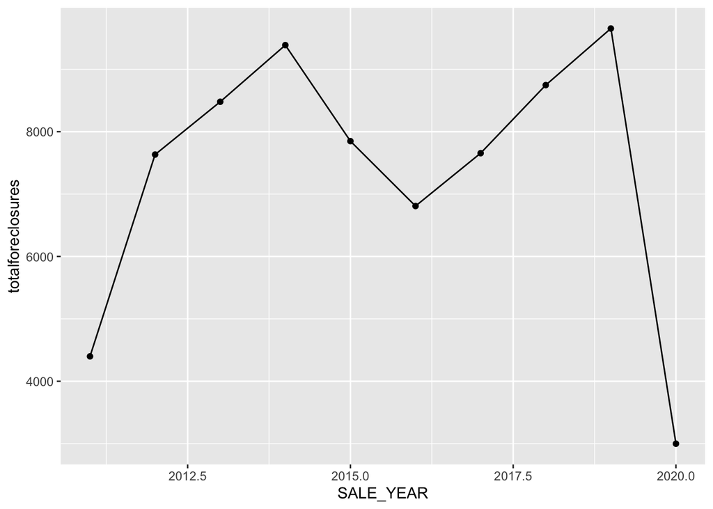

Fore-closures went up and down, but it’s strange seeing this number dip in 2020.